# Opportunity for Income Predictor, place-level

Author

JP Walsh

Published

March 2, 2026

## Overview

*Program for the creation of the Opportunity for Income Predictor at the place level*

**Purpose**: This document produces place-level estimates of household income at the 20th, 50th (median), and 80th percentiles using American Community Survey (ACS) microdata. These metrics help assess economic opportunity and income distribution across U.S. Census places (cities, towns, and Census-designated places).

**Output**: A longitudinal CSV file containing income percentiles, confidence intervals, and quality flags for the 486 largest U.S. places (excluding Puerto Rico) across multiple years.

**Expected Runtime**: 30-60 minutes depending on server capacity and data volume. The ACS microdata is large (~1-2GB per year) and requires significant computing resources.

**Geographic Unit**: Census “places” are incorporated places (cities, towns) and Census Designated Places (CDPs) that represent concentrations of population. This analysis focuses on the 486 largest places in the U.S.

**Authors**: ACS Code initially written by Tina Chelidze and updated by JP Walsh 2022-2023 & in 2025.

**Data Source**: Primary data derived from the IPUMS API.

**Methodology**: Based on processes developed by Paul Johnson and Kevin Werner in SAS.

## Output Data Dictionary

The final output file contains the following variables:

- **year**: ACS survey year
- **state**: State FIPS code (2 digits)
- **place**: Census place code (5 digits)
- **pctl_income_20**: 20th percentile of household income (dollars) - 20% of households earn this amount or less
- **pctl_income_20_lb**: Lower bound of 95% confidence interval for 20th percentile
- **pctl_income_20_ub**: Upper bound of 95% confidence interval for 20th percentile
- **pctl_income_20_quality**: Quality flag (1=best, 3=worst) based on geographic allocation and sample size
- **pctl_income_50**: 50th percentile (median) of household income (dollars)
- **pctl_income_50_lb**: Lower bound of 95% confidence interval for median
- **pctl_income_50_ub**: Upper bound of 95% confidence interval for median
- **pctl_income_50_quality**: Quality flag for median income
- **pctl_income_80**: 80th percentile of household income (dollars) - 80% of households earn this amount or less
- **pctl_income_80_lb**: Lower bound of 95% confidence interval for 80th percentile
- **pctl_income_80_ub**: Upper bound of 95% confidence interval for 80th percentile
- **pctl_income_80_quality**: Quality flag for 80th percentile

### Quality Flag Definitions

The quality flags indicate reliability based on geographic allocation and effective sample size:

- **Quality 1**: PUMA(s) entirely contained within place boundaries + adequate sample (n≥30)
- **Quality 2**: PUMA(s) partially overlap place boundaries + adequate sample (n≥30)
- **Quality 3**: PUMA(s) have complex geographic overlaps + adequate sample (n≥30)
- **NA (suppressed)**: Effective sample size < 30 (insufficient data for reliable estimates)

**Note**: Unlike counties which have complete coverage, this analysis focuses on the 486 largest places only.

## Important Notes and Warnings

**AWS Access (Internal Users)**: If using the AWS feature, enter your passkey into your environment using `Sys.setenv()`. Authentication steps are explained in this [blog](https://www.gormanalysis.com/blog/connecting-to-aws-s3-with-r/). You must request access to the access key.

**Computing Requirements**: The ACS microdata is large (1-2GB per year) and requires significant RAM (8GB+ recommended) and processing time. Use a server with adequate computing power.

**Critical File Path Requirement**: Ensure no folders in your repository filepath contain the acronym “UMF” - this will cause an error in the `extract_ipums_aws()` function. Check your file path using `here::here()`.

**Data Exclusions**: Puerto Rico (statefip = 72) is excluded from the analysis.

## Parameters Guide

This document uses several key parameters that control data processing:

- **params$year**: The ACS year to process (e.g., “2024”). Set in the YAML header.
- **single_year_update**: Set to “Yes” when adding one new year to existing data; “No” when reprocessing all years for validation.
- **existing_years**: Vector of all previously processed years. Update this when adding new years.
- **ipums_extract_date**: Date of the IPUMS data extract (format: “mm_dd_yy”). Update only when re-pulling data from IPUMS.
- **ipums_repwt_extract_date**: Date of the replicate weights extract. Should match IPUMS extract date.

## Housekeeping

### Load Required Packages

Load all necessary R packages. If you do not have an IPUMS API key, create one via the [IPUMS website](https://www.ipums.org/).

**Key packages**: - `ipumsr`: Interface to IPUMS API for downloading ACS microdata - `srvyr`: Survey-weighted statistics with replicate weights - `tidyverse`: Data manipulation and visualization - `aws.s3`: AWS S3 integration for data storage (optional)

```r
library(tidyverse)
library(Hmisc)
library(ipumsr)
library(reactable)
library(srvyr)
library(scales)

options(scipen = 999)

theme_set(theme_minimal())

# DO NOT PUSH YOUR API KEY. You only have to run this once and then comment it out as below.
#set_ipums_api_key("Your KEY", save = TRUE)

# AWS configuration (for internal users with access)
s3_dir <- "metric_name/data/acs"
my_bucket <- "mobility-from-poverty-test"

# Source custom functions
# extract_ipums_aws: Downloads ACS microdata from IPUMS API or retrieves from AWS S3
source(here::here("functions", "API", "extract_ipums_aws.R"))
# ipums_repwt_household_aws: Downloads household-level replicate weights for standard errors
source(here::here("functions", "API", "ipums_repwt_household_aws.R"))
# evaluate_final_data: Validates output data structure and completeness
source(here::here("functions", "testing", "evaluate_final_data.R"))
# finalize_metric: Cleans confidence intervals and formats final output
source(here::here("03_opportunities-for-income", "R", "finalize_metric.R"))
# calc_income_quantiles: Calculates income percentiles using survey weights
source(here::here("03_opportunities-for-income", "R", "calc_income_quantiles.R"))
```

### Extract Dates

Date of IPUMS extract. Denote the latest date that the IPUMS extract was changed and pulled both for the overall data and the repweights. The recommended date notation format is “mm_dd_yy”.

**Important**: These dates serve as version control for the IPUMS data extracts. Only update these dates when you actually re-pull data from IPUMS with changes (new variables, years, or corrections). For internal reviewers using AWS, keep these dates as last entered by the metric lead unless you intend to modify the extract.

**Why separate dates?**: Household data and replicate weights are extracted separately from IPUMS, so they may have different pull dates.

```r
ipums_extract_date <- "02_13_25"
ipums_repwt_extract_date <- "02_13_25"
```

### Single Year Update Flag

If this is to update a single year of new data please set single_year_update to “Yes”. If not, set it to “No”.

**When to use “Yes”**: Adding one new year (e.g., 2024) to existing historical data. The program will process only the new year and exit before validation.

**When to use “No”**: Reprocessing all years or running full validation on the complete longitudinal dataset.

```r
single_year_update = "No"
```

### Define Existing Years

Define all years for which intermediate data files already exist. When adding a new year, add it to this vector after successfully processing that year.

**Update procedure**: After successfully running this script with a new year and `single_year_update = "Yes"`, add that year to this vector for future validation runs.

```r
existing_years <- c("2014", "2015", "2016", "2017", "2018", "2019", "2021", "2022", "2023", "2024")
```

## Read ACS Data

### Define Survey Years

Read in the ACS extracts using the `extract_ipums()` function. The survey list defines which ACS years to download from IPUMS.

**Survey naming convention**: IPUMS uses the format “usYYYYa” for 1-year ACS data (e.g., “us2024a” for 2024 1-year ACS).

**To see available surveys**: Run `get_sample_info("acs")` to view all available ACS surveys and their IPUMS identifiers.

```r
acs_surveys <- list(paste0("us", params$year, "a"))
```

### Household-Level Data

Run extract. This will trigger an import process through IPUMS or retrieve cached data from AWS S3 if available.

**Key variables extracted**: - **HHWT**: Household weight for statistical weighting - **HHINCOME**: Total household income in the past 12 months - **PERNUM**: Person number within household (we use PERNUM=1 to count each household once) - **GQ**: Group quarters status (we keep only households, not institutional settings) - **PUMA**: Public Use Microdata Area (geographic unit) - **ADJUST**: Inflation adjustment factor to standardize income across survey periods

**Extract versioning**: If a new IPUMS pull is required, update the `extract_date` argument above. The extract only needs updating if changes or additions are required from IPUMS (new years, variables, or corrections).

**Processing note**: Add detail to your extract description so it’s clear what the extract was used for when reviewing IPUMS extracts later.

```r
acs <- extract_ipums_aws(
  extract_name = paste0("umf_data_", params$year, "_income_all"),
  extract_date = ipums_extract_date,
  extract_description = paste0("Microdata pull for Mobility Metric Predictors.
  American Community Survey, overall,", params$year, "(1-year)."),
  survey = acs_surveys
)
```

Isolate data to include each household only once. ACS microdata contains one record per person, but we need household-level income statistics.

**Why PERNUM == 1?**: The PERNUM variable identifies person number within a household. Filtering to PERNUM == 1 selects only the first person listed in each household (typically the householder), ensuring we count each household exactly once. The HHINCOME variable is the same for all members of a household, so we only need one record per household.

```r
acs_hh <- acs %>%
  filter(pernum == 1)
```

Look at the distribution of survey samples in the data. The number of unique samples in the data should match the number of surveys selected in the `extract_ipums()` function above.

```r
count(acs_hh, sample)
```

```
# A tibble: 1 × 2
  sample         n
  <fct>      <int>
1 2024 ACS 1531614
```

### Replicate Weights

Read in household-level replicate weights for the entire population. These will be used in creating standard errors and confidence intervals for the income quantile calculations.

**What are replicate weights?**: The ACS uses replicate weights to estimate variance and standard errors for survey statistics. Each of the 80 replicate weights represents a slightly different resampling of the data, allowing us to calculate how much uncertainty exists in our estimates.

**Why separate from main data?**: Replicate weights are stored separately in IPUMS due to file size. The main extract contains 1 weight (HHWT), while the replicate weight extract contains 80 weights (REPWT1-REPWT80).

```r
repwts <- ipums_repwt_household_aws(
  extract_name = paste0("household_replicate_weights_", params$year, "_1year"),
  extract_date = ipums_repwt_extract_date,
  extract_description = paste0("Household replicate weights for Income Opportunities
  Metric Predictors. American Community Survey,", params$year, "(1-year)."),
  survey = acs_surveys
)  %>%
  select(-cbserial, -cbpernum)
```

Look at the distribution of ACS survey samples in the data. The number of different samples should align with the number of surveys selected in the extract ipums function.

```r
count(repwts, sample)
```

```
# A tibble: 1 × 2
  sample         n
  <fct>      <int>
1 2024 ACS 1348408
```

Remove the sample variable.

```r
repwts_hh <- repwts %>%
  select(-sample)
```

### Merge on repwts

Merge the replicate weights onto the ACS samples using the unique person identifier.

```r
length(unique(pull(acs_hh, unique_person_id)))
```

```
[1] 1531614
```

```r
length(unique(pull(repwts_hh, unique_person_id)))
```

```
[1] 1348408
```

```r
acs_combined <-
  left_join(
    acs_hh,
    repwts_hh,
    by = "unique_person_id"
  )

length(unique(pull(acs_combined, unique_person_id)))
```

```
[1] 1531614
```

```r
rm(acs_hh)
rm(repwts_hh)
```

## Clean Data

### Handle Missing Values

Missing data is reported in various ways by IPUMS. This step identifies missing values in key variables and converts them to R’s standard NA format.

**IPUMS missing value conventions**: - Numeric variables use special codes (e.g., 9999999) to indicate missing data - These must be converted to NA for proper statistical analysis

#### Vacancy Status

- **Vacancy:** reported as “0”. Note there should be no vacancy results by default of the structure of census data read in (all should be “0”) because we filter to occupied housing units through the household-level extract. Confirm this is true with the following test.

```r
stopifnot(all(acs_combined$vacancy == "0"))
```

#### Household Income

- **HHINCOME:** Missing values reported as “9999999”.

**Why are some values missing?**: Some households may have: - Refused to report income - Not known their income at survey time  
- Other data quality issues

These missing values are legitimate and will be excluded from percentile calculations. Note there are no vacant properties in the data by default of the household-level structure.

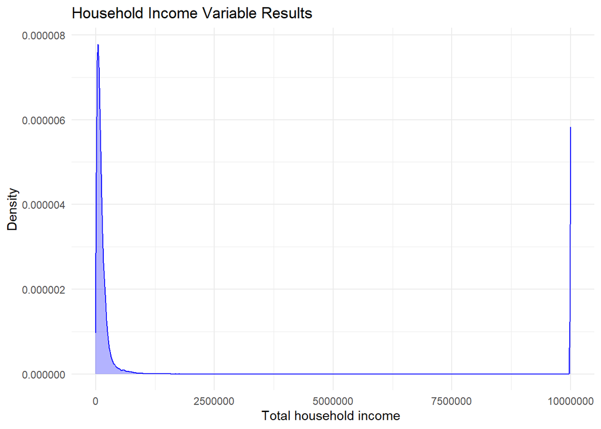

```r
acs_combined %>%
  ggplot(aes(x = hhincome)) +
  geom_density(color = "blue", fill = alpha("blue", 0.3)) +
  theme_minimal() +
  ggtitle("Household Income Variable Results") +
  ylab("Density")
```

Turn the missing/“not in universe” values for the `hhincome` variable into NAs. Rename to the more meaningful “household_income”.

```r
acs_clean <- acs_combined %>%
  mutate(household_income = ifelse(hhincome == 9999999, NA_integer_,
                          hhincome)
  )
```

Look at distribution of `household_income` after adjustment. Some outliers will still exist but bunching around the missing value should not be present.

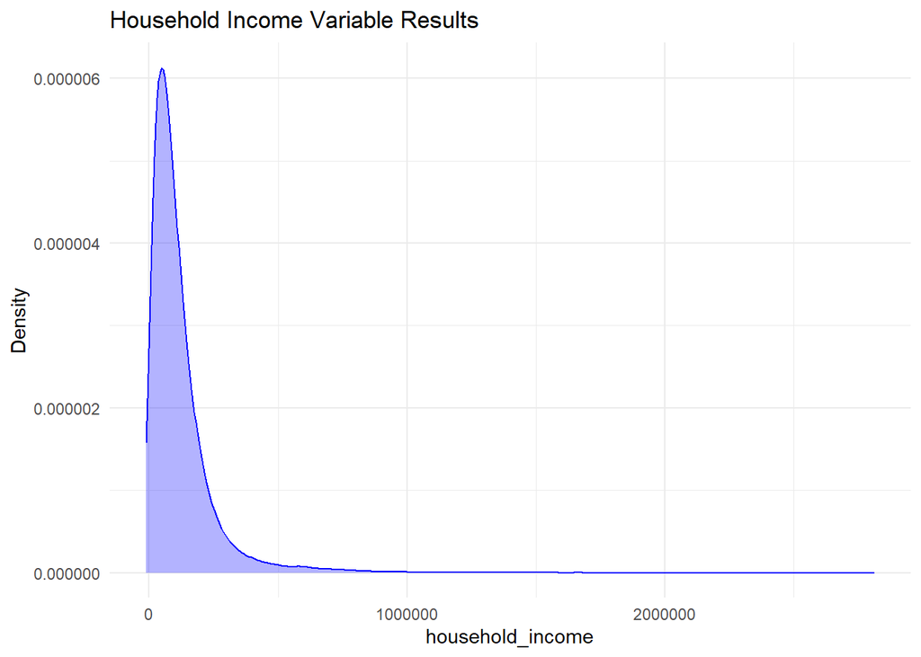

```r
acs_clean %>%
  ggplot(aes(x = household_income)) +
  geom_density(adjust = 5, color = "blue", fill = alpha("blue", 0.3)) +
  theme_minimal() +
  ggtitle("Household Income Variable Results") +
  ylab("Density")
```

### Filter to Households Only

Select our group quarters - we want to keep only households (not group quarters like dormitories, prisons, or nursing homes).

**Group Quarters (GQ) definitions**: - **Households under 1970 definition**: Traditional family households - **Additional households under 1990 definition**: Expanded household definition - **Additional households under 2000 definition**: Further expanded to include more household types - **Group quarters**: Institutional and non-institutional group living situations (excluded)

**Why exclude group quarters?**: Household income is not a meaningful concept for institutional populations. We focus on private households.

```r
acs_clean %>%
  group_by(gq) %>%
  count()
```

```
# A tibble: 5 × 2
# Groups:   gq [5]
  gq                                                n
  <fct>                                         <int>
1 Households under 1970 definition            1347429
2 Additional households under 1990 definition     894
3 Group quarters--Institutions                  84422
4 Other group quarters                          98784
5 Additional households under 2000 definition      85
```

```r
acs_clean <- acs_clean %>%
  filter(gq %in% c("Households under 1970 definition",
                   "Additional households under 1990 definition",
                   "Additional households under 2000 definition"))
```

Check that group quarters fall only into household categories.

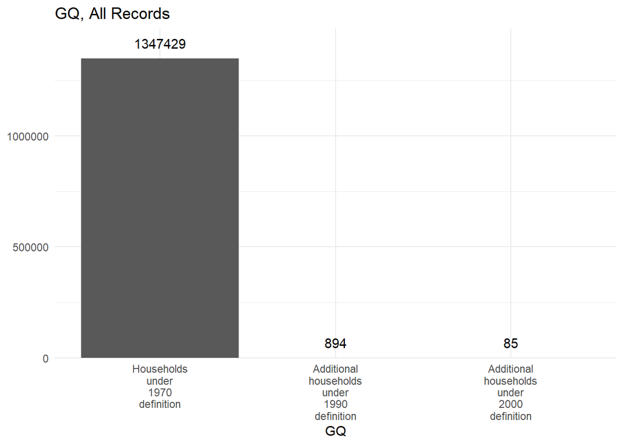

```r
acs_clean %>%
  count(gq) %>%
  ggplot(mapping = aes(x = gq, y = n)) +
  geom_col() +
  theme_minimal() +
  ggtitle("GQ, All Records") +
 geom_text(mapping = aes(label = n), vjust = -1) +
  scale_y_continuous(expand = expansion(mult = c(0, 0.1))) +
  labs(x = "GQ",
       y = NULL) +
  scale_x_discrete(labels = label_wrap(10))
```

## Geographic Crosswalk

### PUMA to Place Mapping

Read in the PUMA to place crosswalk file. This file is created by the program `generate_puma_place_crosswalks.rmd` in the geographic-crosswalks folder.

**Why is a crosswalk needed?**: ACS microdata is released at the PUMA (Public Use Microdata Area) level to protect respondent privacy. PUMAs contain ~100,000+ people but do not align with place boundaries. We must use a crosswalk to allocate PUMA-level data to places.

**AFACT variable**: The crosswalk contains an allocation factor (AFACT) representing the proportion of a PUMA’s population that falls within each place. For example, if a PUMA overlaps with a city capturing 40% of that PUMA’s population, records from that PUMA will be weighted by 0.40 for that place.

**Geographic allocation quality**: Places composed of PUMAs entirely within their boundaries receive quality flag 1; places requiring geographic allocation receive flags 2 or 3 depending on complexity.

**Coverage note**: This crosswalk includes the 486 largest U.S. Census places only.

```r
puma_place_crosswalk <- read_csv(
  here::here("geographic-crosswalks", "data", "crosswalk_puma_to_place.csv")
)
```

Create a version with just unique places for creating a version of the data that matches the UMF place list.

**Note**: Puerto Rico (statefip = 72) is excluded from analysis. The place list includes 486 of the largest U.S. places.

```r
place_list <- puma_place_crosswalk %>%
  select(statefip, place) %>%
  filter(statefip != 72) %>%
  unique()
```

## Merge Crosswalk

### Apply Time-Specific Crosswalk

Create a variable in the ACS data indicating whether the survey is pre or post-2022. This will be used to join on the correct crosswalk information.

**Why two crosswalks?**: PUMA boundaries were redrawn in 2022 based on 2020 Census data. Data from 2021 and earlier uses 2010-based PUMAs; 2022+ uses 2020-based PUMAs. We must apply the appropriate crosswalk for each time period.

```r
acs_clean <- acs_clean %>%
  mutate(crosswalk_period = ifelse(year < 2022, "pre-2022", "2022"))
```

Check that the assignment worked. All years prior to 2022 should be designated “pre-2022”.

```r
count(acs_clean, crosswalk_period, year)
```

```
# A tibble: 1 × 3
  crosswalk_period  year       n
  <chr>            <int>   <int>
1 2022              2024 1348408
```

Join the cleaned ACS data onto the crosswalk.

```r
acs_crosswalked <- left_join(
  acs_clean,
  puma_place_crosswalk,
  by = c("crosswalk_period", "statefip","puma"),
  relationship = "many-to-many"
)

rm(acs_clean)
```

```r
acs_crosswalked %>%
  group_by(place, statefip) %>%
  count()
```

```
# A tibble: 536 × 3
# Groups:   place, statefip [536]
   place statefip     n
   <chr> <chr>    <int>
 1 00562 06         718
 2 00884 06         507
 3 01000 36         390
 4 01000 39        2131
 5 01000 48        2037
 6 01000 51         833
 7 01924 48        1356
 8 02000 06        4853
 9 02000 35        2316
10 02000 42         262
# ℹ 526 more rows
```

Drop any observations with NA for `afact` (i.e. there is no place of interest overlapping this PUMA).

```r
count(acs_crosswalked, is.na(afact))
```

```
# A tibble: 2 × 2
  `is.na(afact)`      n
  <lgl>           <int>
1 FALSE          754260
2 TRUE           748386
```

```r
acs_crosswalked <- acs_crosswalked %>%
  drop_na(afact)
```

Also filter out cases where `afact` is equal to zero. These cases will not be counted in the metric calculation.

```r
count(acs_crosswalked, afact == 0)
```

```
# A tibble: 1 × 2
  `afact == 0`      n
  <lgl>         <int>
1 FALSE        754260
```

```r
acs_crosswalked <- acs_crosswalked %>%
  filter(afact > 0)
```

### Adjust Weights for Geographic Allocation

Adjust the household weight and all replicate weights to account for PUMA-to-place mapping.

**Why adjust weights?**: When a PUMA spans multiple places or extends beyond a place, we multiply the household weight by the allocation factor (AFACT) to proportionally distribute that PUMA’s households to each place. For example, if AFACT = 0.4, we assign 40% of the household’s weight to that place.

**Applies to all weights**: Both the main household weight (HHWT) and all 80 replicate weights (REPWT1-REPWT80) must be adjusted to maintain statistical validity.

```r
select(acs_crosswalked, hhwt, repwt1, repwt80, afact)
```

```
# A tibble: 754,260 × 4
    hhwt repwt1 repwt80  afact
   <dbl>  <dbl>   <dbl>  <dbl>
 1    11     16      21 0.0326
 2    61     68      56 0.752
 3    67     67      68 0.968
 4   199     61      64 0.135
 5    93    170      86 0.135
 6    53     79      48 0.497
 7   107    172     112 0.968
 8   114     42      33 0.595
 9   208    308     284 0.968
10   117     35     222 0.0531
# ℹ 754,250 more rows
```

```r
acs_crosswalked <- acs_crosswalked %>%
  mutate(hhwt = hhwt * afact,
         across(matches("repwt[0-9]+"), ~.x * afact))

select(acs_crosswalked, hhwt, repwt1, repwt80, afact)
```

```
# A tibble: 754,260 × 4
      hhwt  repwt1 repwt80  afact
     <dbl>   <dbl>   <dbl>  <dbl>
 1   0.359   0.522   0.685 0.0326
 2  45.9    51.1    42.1   0.752
 3  64.9    64.9    65.8   0.968
 4  26.9     8.24    8.65  0.135
 5  12.6    23.0    11.6   0.135
 6  26.3    39.3    23.9   0.497
 7 104.    167.    108.    0.968
 8  67.9    25.0    19.6   0.595
 9 201.    298.    275.    0.968
10   6.21    1.86   11.8   0.0531
# ℹ 754,250 more rows
```

### Inflation Adjustment

This section makes two adjustments to then dollar `household_income` values that account for inflation. First, we apply CPI adjustments for all values to the latest year in dollar value.

This adjustment table is provided by the [IPUMS website](https://usa.ipums.org/usa/cpi99.shtml). IPUMS updates this table for new ACS years annually, users may have to update the link in the ‘read_html’ statement below.

```r
cpi_data <- rvest::read_html("https://usa.ipums.org/usa/cpi99.shtml") %>%
    rvest::html_element("table") %>%
    rvest::html_table() %>%
    janitor::clean_names() %>%
    select(data_year, income_year, cpi_to_1999 = cpi99) %>%
    mutate(
      data_year = as.numeric(data_year),
      income_year = parse_number(income_year),
      cpi_to_1999 = as.numeric(cpi_to_1999)
    ) %>%
    filter(!is.na(data_year)) # drop the second 2000 row which gets parsed as NA due to a trailing space
```

Convert all values to 1999 dollars.

```r
acs_crosswalked <- acs_crosswalked %>%
  left_join(cpi_data, by = c("year" = "data_year")) %>%
  mutate(
    household_income = household_income*cpi_to_1999
  ) %>%
  select(-cpi_to_1999)
```

Now we want to adjust all values to the latest year available. This value comes from adjustment values also provided by [IPUMS](https://cps.ipums.org/cps/cpi99.shtml) and is scraped below. We adjust all values to the inflation year set in the parameters argument.

```r
cpi_data <- rvest::read_html("https://cps.ipums.org/cps/cpi99.shtml") %>%
    rvest::html_nodes("table") %>%
    rvest::html_table()

alternate_factor <- cpi_data[[2]] %>%
    janitor::clean_names() %>%
    select(income_year, alternate_factor) %>%
    mutate(
      income_year = str_sub(income_year, 1, 4),
      income_year = as.numeric(income_year),
      alternate_factor = as.numeric(alternate_factor)
    ) %>%
  filter(income_year == params$inflation_year) %>%
  select(alternate_factor) %>%
  pull()
```

```r
acs_crosswalked <- acs_crosswalked %>%
  mutate(
    household_income = household_income*alternate_factor
  )
```

Apply the ADJUST variable to `household_income`.

**What is ADJUST?**: IPUMS provides an inflation adjustment factor that converts income amounts to constant dollars for the survey year. The ADJUST factor accounts for: - Inflation between the income reference period and survey year - Households being surveyed at different times during the year - Price level changes within the survey year

**Why multiply income by ADJUST?**: This standardizes all income values to the same time period, making them comparable across survey months.

```r
acs_crosswalked <- acs_crosswalked %>%
  mutate(
    household_income = household_income*adjust
  )
```

Confirm there are no missing values remaining in the data set for the household income variable.

```r
acs_crosswalked %>%
  filter(is.na(household_income)) %>%
  count()
```

```
# A tibble: 1 × 1
      n
  <int>
1     0
```

Confirm there are no vacant properties included in the data.

```r
acs_crosswalked %>%
  filter(is.na(vacancy)) %>%
  count()
```

```
# A tibble: 1 × 1
      n
  <int>
1     0
```

## Create Income Metric: All Households

Create the income metric for all households (no demographic subgroups).

**Objective**: Calculate the 20th, 50th (median), and 80th percentiles of household income by place.

**Interpretation**: - **20th percentile**: 20% of households earn this amount or less (lower-income benchmark) - **50th percentile (median)**: Half of households earn more, half earn less (typical income) - **80th percentile**: 80% of households earn this amount or less (higher-income benchmark)

**Statistical approach**: - Weighted by household weight (HHWT × AFACT) to represent population - Uses replicate weights to calculate 95% confidence intervals - Applies jackknife variance estimation (JK1 method with 80 replicates)

### Pre-drop Suppressed Cells

#### Calculate Effective Sample Size

First, to save time when processing the metric, calculate the effective sample count for each place.

**Effective sample calculation**: Sum of the AFACT variable for all records in a place. This represents the “effective” number of survey responses after geographic allocation.

**Why not just count records?**: A record with AFACT = 0.4 contributes only 40% of a full sample, so simple record counts would overstate sample size for places with split PUMAs.

**Suppression threshold**: Places with effective sample < 30 are suppressed (set to NA) because estimates would be too unreliable. This follows standard statistical disclosure practices.

```r
acs_all <- acs_crosswalked %>%
  group_by(year, sample, crosswalk_period, statefip, place) %>%
  mutate(effective_sample = sum(afact)) %>%
  ungroup()

# calculate the number of statistics after suppressing values
acs_all %>%
  group_by(year, sample, crosswalk_period, statefip, place) %>%
  summarize(
    effective_sample = max(effective_sample)
  ) %>%
  ungroup() %>%
  summarize(
    original_stats = n(),
    unsuppressed_stats = sum(effective_sample >= 30)
  )
```

```
# A tibble: 1 × 2
  original_stats unsuppressed_stats
           <int>              <int>
1            486                486
```

Remove records from places below the size quality cutoff.

```r
acs_all <- acs_all %>%
  filter(effective_sample >= 30)
```

### Calculate Metric

Calculate the place-level income percentiles with confidence intervals.

**Survey methodology**: The `calc_income_quantiles()` function: 1. Sets up survey design with replicate weights (JK1 method) 2. Calculates 20th, 50th, 80th percentiles with survey weights 3. Generates 95% confidence intervals using replicate weights 4. Returns geographic allocation quality from crosswalk

**Processing note**: Data is split by state to improve computational efficiency with large datasets.

```r
results_all <- acs_all %>%
  group_split(statefip) %>%
  map_dfr(~ calc_income_quantiles(.data = .x, .geo_level = place))
```

Clean up the confidence interval bounds and sort the data.

```r
results_all <- finalize_metric(results_all,
                               .geo_level = place)
```

```r
rm(acs_all)
```

## Add Suppressed Rows to Data

### Include All Places in Output

To create the metric we suppressed places that did not meet the threshold for sample size, but we need to include these in the final data as NA values for completeness.

**Why add back suppressed places?**: Users need a complete list of all 486 places (even those with NA values) to avoid confusion about which places were excluded vs. missing data.

Expand the place_list file so it includes every year in the results. Join the results onto this file and test that the number of records matches the total number of places we anticipate.

**Expected count**: 486 places per year (covering the largest U.S. Census places).

```r
expanded_place_list <- place_list %>%
  left_join(results_all, by = c("statefip", "place"), relationship = "many-to-many") %>%
  mutate(geoid = paste0(statefip, place)) %>%
  expand(year, geoid) %>%
  mutate(statefip = str_sub(geoid, 1, 2),
         place = str_sub(geoid, 3, 7))

results_all_expand <- expanded_place_list %>%
  left_join(results_all, by = c("year", "statefip", "place")) %>%
  filter(!is.na(year))

stopifnot(nrow(results_all_expand) == 486 * n_distinct(results_all_expand$year))
```

## Data Quality Flags

### Assign Quality Indicators

Add a flag for data quality - a numeric variable between 1 and 3 with 1 representing the best quality and 3 representing the worst.

**Quality flag basis**: 1. **Geographic allocation quality** from the crosswalk file (how cleanly PUMAs map to places) 2. **Effective sample size** (must be ≥30 to report estimates)

**Quality flag assignment**: - **Quality 1**: PUMAs entirely within place + adequate sample - **Quality 2**: PUMAs partially overlap place + adequate sample  
- **Quality 3**: Complex PUMA overlaps + adequate sample - **NA**: Effective sample < 30 (all income values also NA)

**Note**: Quality flags are identical for all three percentiles (20th, 50th, 80th) within a place-year because they’re based on the same underlying sample and geographic allocation.

```r
metrics_income_all <- results_all_expand %>%
  mutate(
    pctl_income_20_quality = if_else(
      is.na(pctl_income_20),
      NA_real_,
      geographic_allocation_quality
    ),
    pctl_income_50_quality = if_else(
      is.na(pctl_income_50),
      NA_real_,
      geographic_allocation_quality
    ),
    pctl_income_80_quality = if_else(
      is.na(pctl_income_80),
      NA_real_,
      geographic_allocation_quality
    )
  )
```

### Write Out Intermediate Data

Save intermediate files for each year to AWS S3 (if available) or local storage.

**Purpose**: Intermediate files allow validation across all years without reprocessing. When adding a new year, we can combine it with existing years for quality checks.

```r
if(isTRUE(bucket_exists(bucket = my_bucket))){
    # write file to S3
    tmp <- tempfile()
    on.exit(unlink(tmp))
    write_csv(metrics_income_all, file = tmp)

    # put object with an upload progress bar
    put_object(tmp, object = paste0(s3_dir, "/metrics_income_all", "_", params$year, ".csv"), bucket = my_bucket,
               show_progress = TRUE, multipart = FALSE)
}
```

```
[1] TRUE
```

### Exit Point for Single Year Updates

If updating a single year, the program ends here. The new year’s data has been saved to intermediate storage.

**Next steps after single year update**: 1. Add the new year to the `existing_years` vector 2. Set `single_year_update = "No"` 3. Re-run to perform validation across all years and create the final longitudinal dataset

```r
if(single_year_update == "Yes"){
  knitr::knit_exit()
}
```

## Validation

### Multi-Year Quality Checks

Validate results for all years of available output. This section runs only when `single_year_update = "No"`.

**Validation objectives**: 1. Check distributions of income percentiles for outliers 2. Verify reasonable year-over-year changes 3. Assess suppression rates by year 4. Confirm quality flag distributions

### Read Intermediate Files

Read in the intermediate files created for each ACS year available.

Function reads the CSVs from intermediate folder or from AWS if the user has access. This combines all years into a single longitudinal dataset for validation.

```r
read_intermediate <- function(year, file_type){

  if(isTRUE(bucket_exists(bucket = my_bucket))) {

    data_year <- s3read_using(FUN=read_csv,
                 bucket = my_bucket,
                 object=paste0(s3_dir, "/metrics_income_", file_type, "_", year, ".csv")) %>%
      mutate(crosswalk_period = as.character(crosswalk_period))


  }
  else{

  read_csv(paste0(here::here("03_opportunities-for-income", "data", "intermediate", "income"),
                  "/", "metrics_income_", file_type, "_", year, ".csv"))
  }

}
```

```r
metrics_income_all <- map_df(.x = existing_years, .f = ~read_intermediate(year = .x,
                                                                          file_type = "all"))
```

```r
metrics_income_all %>%
  select(pctl_income_20:pctl_income_80) %>%
  summary()
```

```
 pctl_income_20   pctl_income_50   pctl_income_80
 Min.   : 11369   Min.   : 29363   Min.   : 60306
 1st Qu.: 26335   1st Qu.: 64166   1st Qu.:127088
 Median : 33390   Median : 77784   Median :149773
 Mean   : 35829   Mean   : 83601   Mean   :162764
 3rd Qu.: 42937   3rd Qu.: 97444   3rd Qu.:185923
 Max.   :105337   Max.   :240381   Max.   :491990
 NA's   :7        NA's   :7        NA's   :7
```

### Visualize Income Distributions

Examine distributions of income percentiles by place for the latest year of data.

**Expected patterns**: - 80th percentile should be higher than 50th (median), which should be higher than 20th - Distributions should be relatively smooth without extreme outliers - Year-over-year distributions should be similar (incomes change gradually) - Places tend to have higher variability than counties due to more diverse local economies

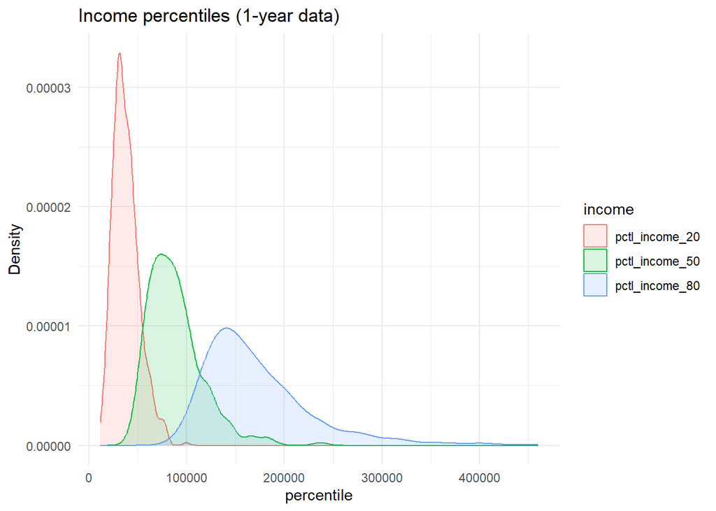

```r
metrics_income_all %>%
  filter(year == params$year) %>%
  select(pctl_income_20, pctl_income_50, pctl_income_80) %>%
  pivot_longer(cols = c(pctl_income_20, pctl_income_50, pctl_income_80), names_to = "income", values_to = "percentile") %>%
  ggplot(aes(x = percentile, color = income, fill = income)) +
  geom_density(alpha = 0.15) +
  theme_minimal() +
  ggtitle("Income percentiles (1-year data)") +
  ylab("Density")
```

Median income distribution over time (inflation adjusted)

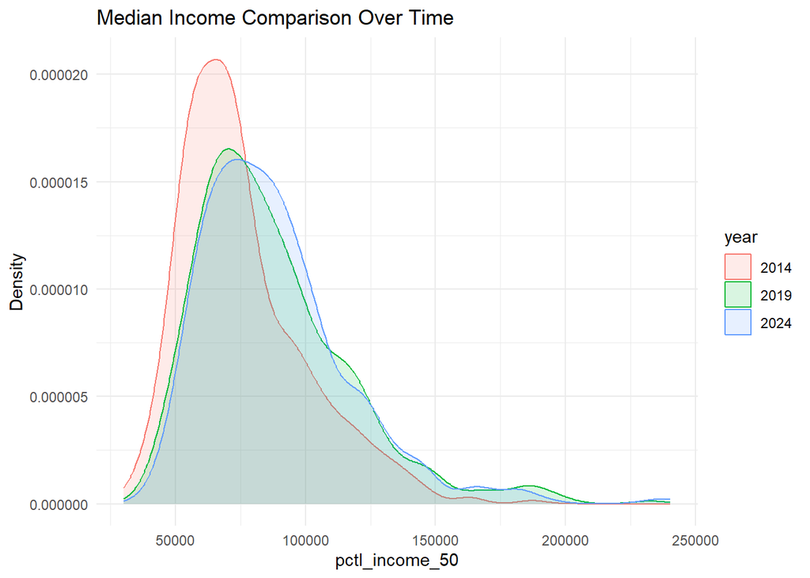

```r
metrics_income_all %>%
  filter(year %in% c(params$year, 2014, 2019)) %>%
  select(year, pctl_income_50) %>%
  mutate(year = as.character(year),
         year = factor(year, levels = c("2014", "2019", params$year))) %>%
  ggplot(aes(x = pctl_income_50, color = year, fill = year)) +
  geom_density(alpha = 0.15) +
  theme_minimal() +
  ggtitle("Median Income Comparison Over Time") +
  ylab("Density")
```

80th percentile income distribution over time (inflation adjusted)

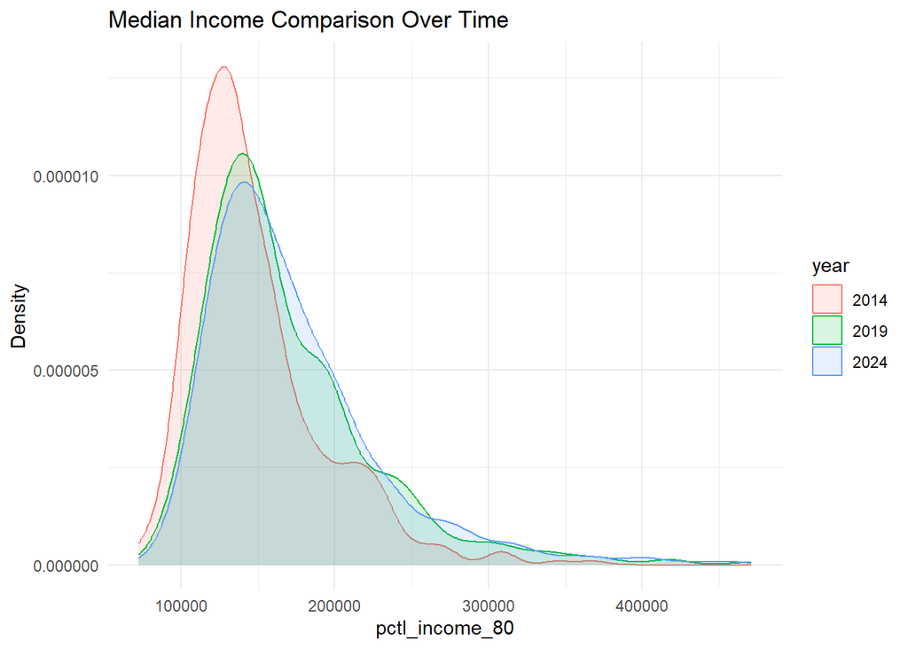

```r
metrics_income_all %>%
  filter(year %in% c(params$year, 2014, 2019)) %>%
  select(year, pctl_income_80) %>%
  mutate(year = as.character(year),
         year = factor(year, levels = c("2014", "2019", params$year))) %>%
  ggplot(aes(x = pctl_income_80, color = year, fill = year)) +
  geom_density(alpha = 0.15) +
  theme_minimal() +
  ggtitle("Median Income Comparison Over Time") +
  ylab("Density")
```

Median income for select places over time

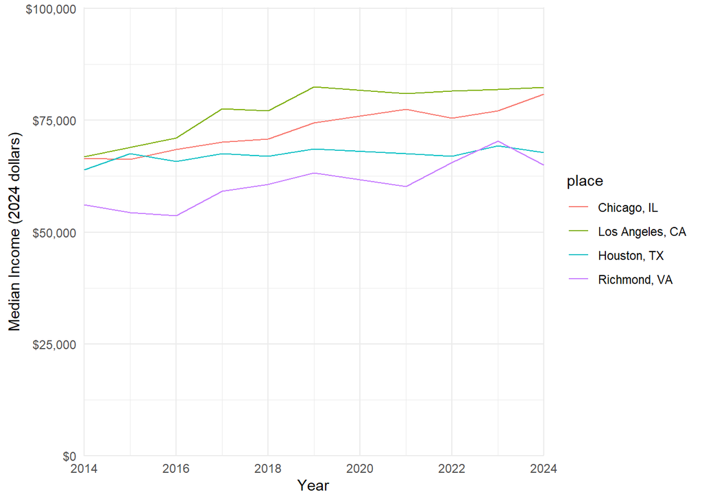

```r
metrics_income_all %>%
  mutate(st_place = paste0(statefip, place)) %>%
  filter(st_place %in% c("1714000", "0644000", "4835000", "5167000")) %>%
  mutate(place = case_when(place == "14000" ~ "Chicago, IL",
                            place == "44000" ~ "Los Angeles, CA",
                            place == "35000" ~ "Houston, TX",
                            place == "67000" ~ "Richmond, VA"),
         place = factor(place, levels = c("Chicago, IL",
                                            "Los Angeles, CA",
                                            "Houston, TX",
                                            "Richmond, VA"))) %>%
  ggplot(aes(year, pctl_income_50, color = place)) +
  geom_line() +
  scale_x_continuous(expand = expansion(mult = c(0.002, 0)),
                     limits = c(2014, 2024)) +
  scale_y_continuous(expand = expansion(mult = c(0, 0.002)),
                     labels = scales::dollar,
                     limits = c(0, 100000)) +
  labs(x = "Year",
       y = "Median Income (2024 dollars)")
```

80th percentile income for select places over time

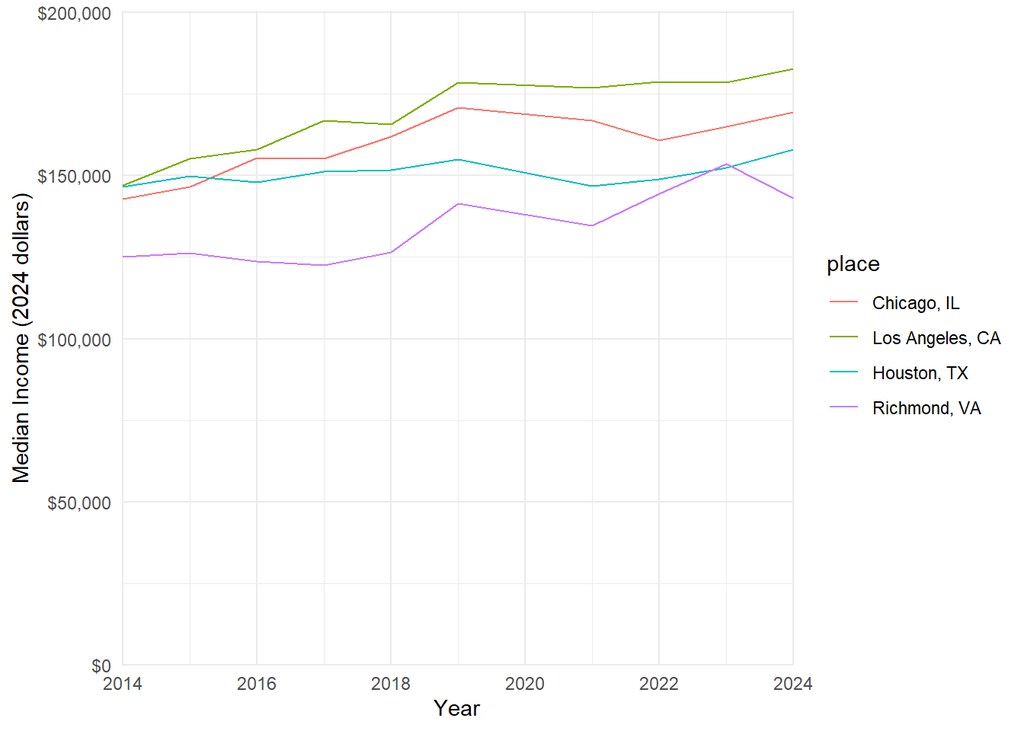

```r
metrics_income_all %>%
  mutate(st_place = paste0(statefip, place)) %>%
  filter(st_place %in% c("1714000", "0644000", "4835000", "5167000")) %>%
  mutate(place = case_when(place == "14000" ~ "Chicago, IL",
                            place == "44000" ~ "Los Angeles, CA",
                            place == "35000" ~ "Houston, TX",
                            place == "67000" ~ "Richmond, VA"),
         place = factor(place, levels = c("Chicago, IL",
                                            "Los Angeles, CA",
                                            "Houston, TX",
                                            "Richmond, VA"))) %>%
  ggplot(aes(year, pctl_income_80, color = place)) +
  geom_line() +
  scale_x_continuous(expand = expansion(mult = c(0.002, 0)),
                     limits = c(2014, 2024)) +
  scale_y_continuous(expand = expansion(mult = c(0, 0.002)),
                     labels = scales::dollar,
                     limits = c(0, 200000)) +
  labs(x = "Year",
       y = "Median Income (2024 dollars)")
```

### Quality Flag Distribution

Examine the counts of the quality flag across all years. We look at quality for `pctl_income_20` - given how the quality variable is created, it will be identical to the quality results for income_50 and income_80.

**Expected distribution**: Most places should have quality flags 2 or 3 (places often span multiple PUMAs). Quality flag 1 is less common than for counties. NA values represent suppressed places (effective sample < 30).

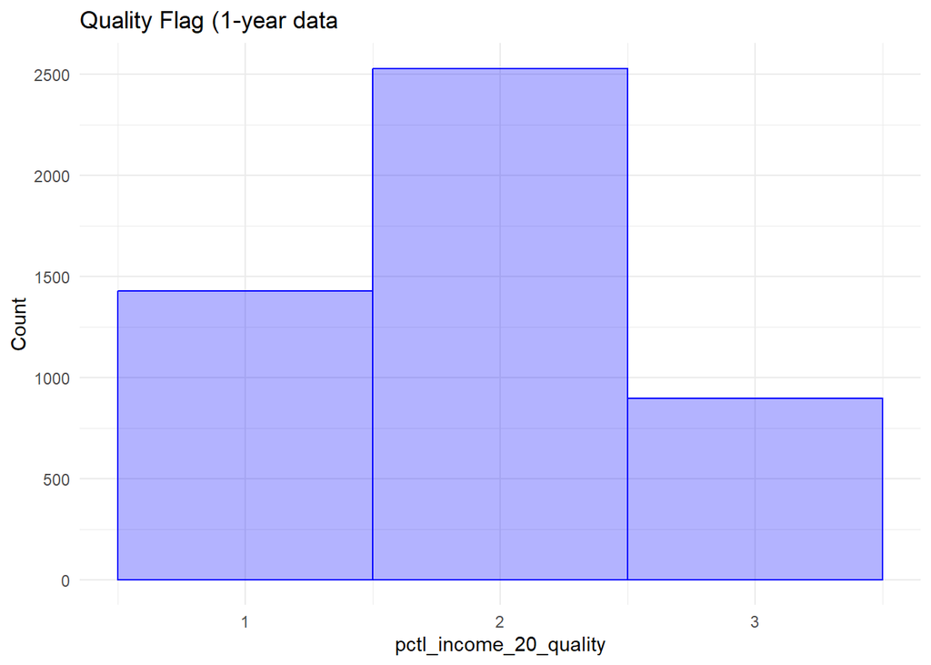

```r
metrics_income_all %>%
  select(pctl_income_20_quality) %>%
  ggplot(aes(x = pctl_income_20_quality)) +
  geom_histogram(color = "blue", fill = alpha("blue", 0.3), binwidth = 1.0) +
  theme_minimal() +
  ggtitle("Quality Flag (1-year data") +
  ylab("Count")
```

### Suppression Rates

Tabulate share of data suppressed by year.

```r
metrics_income_all %>%
  group_by(year) %>%
  filter(is.na(pctl_income_20)) %>%
  count()
```

```
# A tibble: 7 × 2
# Groups:   year [7]
   year     n
  <dbl> <int>
1  2014     1
2  2015     1
3  2016     1
4  2017     1
5  2018     1
6  2019     1
7  2021     1
```

## Final Test and Export

### Prepare Final Dataset

Finalize variable names and structure for the final longitudinal dataset.

```r
metrics_income_all <- metrics_income_all %>%
  rename("state" = "statefip")
```

Order the variables how we want.

```r
metrics_income_all <- metrics_income_all %>%
  select(year, state, place, pctl_income_20, pctl_income_20_lb,
         pctl_income_20_ub,
         pctl_income_20_quality,
         pctl_income_50, pctl_income_50_lb,
         pctl_income_50_ub,
         pctl_income_50_quality,
         pctl_income_80, pctl_income_80_lb,
         pctl_income_80_ub,
         pctl_income_80_quality)
```

### Automated Quality Checks

Run file through the `evaluate_final_data()` function. This validates: - Correct variable names and types - Expected number of records (486 × number of years) - No missing geographic identifiers - Confidence intervals properly bounded (LB ≤ estimate ≤ UB) - Data completeness against expected evaluation form

```r
evaluate_final_data(data = metrics_income_all, exp_form_path = here::here("10a_final-evaluation", "evaluation_form_income_overall_place.csv"), geography = "place", subgroups = FALSE, confidence_intervals = TRUE)
```

```
[1] "This data passes all tests!"
```

### Export as CSV

```r
metrics_income_all %>%
  head(10)
```

```
# A tibble: 10 × 15
    year state place pctl_income_20 pctl_income_20_lb pctl_income_20_ub
   <dbl> <chr> <chr>          <dbl>             <dbl>             <dbl>
 1  2014 01    03076         17245.            15240.            20587.
 2  2014 01    07000         17779.            14705.            19651.
 3  2014 01    35896         34757.            31281.            36896.
 4  2014 01    37000         22726.            19785.            27271.
 5  2014 01    50000         20854.            18715.            22726.
 6  2014 01    51000         22458.            19250.            25266.
 7  2014 01    77256         22191.            17646.            26736.
 8  2014 02    03000         44649.            33687.            53472.
 9  2014 04    04720         35292.            32123.            41441.
10  2014 04    07940         29811.            25132.            38366.
# ℹ 9 more variables: pctl_income_20_quality <dbl>, pctl_income_50 <dbl>,
#   pctl_income_50_lb <dbl>, pctl_income_50_ub <dbl>,
#   pctl_income_50_quality <dbl>, pctl_income_80 <dbl>,
#   pctl_income_80_lb <dbl>, pctl_income_80_ub <dbl>,
#   pctl_income_80_quality <dbl>
```

```r
write_csv(metrics_income_all,
          here::here("03_opportunities-for-income", "final", "metrics_income_place_all_longitudinal.csv"))
```